# Analisis Manajemen Operasional Bisnis: Identifikasi Kategori Film Terpopuler pada Sistem Sakila

Halimatussa’diyah - M0725080 - Kelas E

2026-05-20

### **Deskripsi Insight: Tren Popularitas Genre Film pada Sistem Operasi Sakila**

Sebagai perusahaan penyewaan film, memahami preferensi pelanggan terhadap genre film tertentu merupakan kunci utama dalam mengoptimalkan manajemen inventaris dan strategi pemasaran. Analisis ini bertujuan untuk mengidentifikasi Top 5 Genre Film Paling Populer (Paling Sering Disewa) di dalam database Sakila.

Data diambil dengan cara mengintegrasikan lima tabel utama: rental, inventory, film, film_category, and category. Dengan mengetahui genre yang memiliki frekuensi sewa tertinggi, manajemen dapat mengambil keputusan berbasis data (data-driven) untuk memprioritaskan alokasi anggaran belanja inventaris DVD baru pada genre-genre dominan tersebut.

### **Koneksi Database Sakila Melalui MySQL**

```r
library(DBI)
library(RMySQL)
library(ggplot2)
library(odbc)

# Mengoneksikan R ke database Sakila di MySQL Workbench
library(DBI)
con2 <- DBI::dbConnect(odbc::odbc(), Driver = "MySQL ODBC 8.0 ANSI Driver",
    Server = "127.0.0.1", Database = "sakila", UID = "root",
    PWD = "halimaa17", Port = 3306)
```

### **Ekstraksi Data: Top 5 Genre Film Terpopuler**

```sql
SELECT c.name AS genre, COUNT(r.rental_id) AS total_rental
FROM rental r
JOIN inventory i ON r.inventory_id = i.inventory_id
JOIN film f ON i.film_id = f.film_id
JOIN film_category fc ON f.film_id = fc.film_id
JOIN category c ON fc.category_id = c.category_id
GROUP BY c.name
ORDER BY total_rental DESC
LIMIT 5;
```

### **Visualisasi Data**

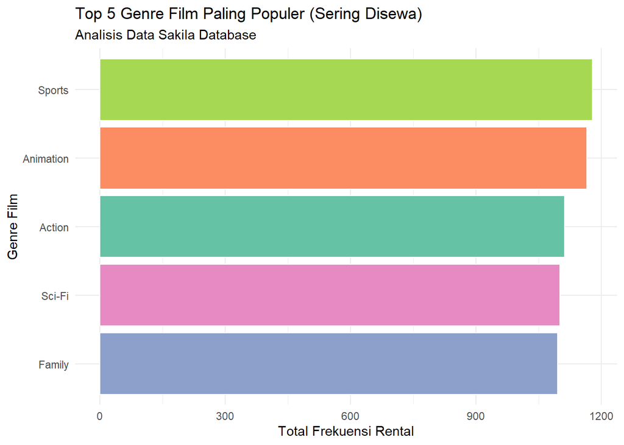

```r
library(ggplot2)

ggplot(data_genre, aes(x = reorder(genre, total_rental), y = total_rental, fill = genre)) +
  geom_bar(stat = "identity", color = "white", show.legend = FALSE) +
  coord_flip() +
  labs(
    title = "Top 5 Genre Film Paling Populer (Sering Disewa)",
    subtitle = "Analisis Data Sakila Database",
    x = "Genre Film",
    y = "Total Frekuensi Rental"
  ) +
  theme_minimal() +
  scale_fill_brewer(palette = "Set2")
```

### **Analisis dan Interpretasi Bisnis**

Berdasarkan grafik visualisasi di atas, kita dapat melihat performa dari masing-masing kategori film pada sistem operasional bisnis Sakila. Kategori ‘Sports’ menempati urutan pertama sebagai genre yang paling sering disewa, disusul oleh ‘Animation’ dan ‘Action’.

Untuk mengukur nilai total transaksi penyewaan dari volume rental tersebut, kita dapat menggunakan pendekatan formula matematika berikut:

$$\text{Total Revenue} = \sum_{i=1}^{n}
(\text{Price}_i \times Q_i)$$
Keterangan: * $Price_i$: Harga sewa per film pada kategori tertentu. * $Q_i$: Jumlah total frekuensi film tersebut disewa oleh pelanggan ($total\_rental$).

### **Kesimpulan dan Rekomendasi Bisnis:**

Pihak manajemen dapat memanfaatkan sistem operasional untuk membuat paket promosi yang menggabungkan film dari kategori terpopuler (seperti *Sports* atau *Animation*) dengan film dari kategori yang memiliki tingkat peminat lebih rendah dalam satu harga khusus. Strategi berbasis data (*data-driven*) ini tidak hanya efektif untuk meningkatkan pendapatan utama perusahaan sesuai dengan formula $\text{Total Revenue}$, melainkan juga membantu mempercepat perputaran sewa dari koleksi DVD lama yang selama ini jarang diminati oleh pelanggan.